[figure not shown]

# Pràctica 1 - Models Conexionistes

## Guillem Miralles Gadea

### 0. Llibreríes:

```python
#Carga de librerías
import keras
from tensorflow.keras.models import Sequential
from tensorflow.keras.utils import to_categorical
from tensorflow.keras.layers import Dense, Dropout, Flatten, Input
from tensorflow.keras.layers import Conv2D, MaxPooling2D
from tensorflow.keras.optimizers import SGD
import numpy as np
import matplotlib.pyplot as plt
import tensorflow as tf
```

# Ejercicio 1

• Implementa el anterior código y comprueba su funcionamiento

• Varía los siguientes parámetros; consulta la ayuda de Keras : (https://keras.io/) y comprueba si se mejora/empeora el funcionamiento:

```
- Añadiendo otra capa de neuronas ocultas antes de la capa de salida. Introduce dropout (considera p=0.5)
- Algoritmos de optimización (por ejemplo el RMSprop).
- Añadiendo otra capa de convolución (16 filtros).
```

### 1. Lectura de dades:

```python
mnist = tf.keras.datasets.mnist
(img_rows, img_cols) = (28,28)
(x_train, y_train),(x_test, y_test) = mnist.load_data()
```

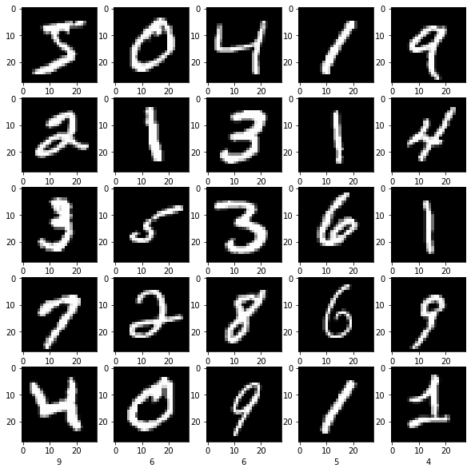

```python
#Visualización de los datos.
plt.figure(figsize=(10,10))
for i in range(25):
    plt.subplot(5,5,i+1)
    plt.imshow(x_train[i], cmap=plt.cm.gray)
    plt.xlabel(y_test[i])
```

### 2. Normalització

```python
y_train = to_categorical(y_train)
y_test = to_categorical(y_test)
x_train, x_test = x_train / 255.0, x_test / 255.0
x_train_cnn = np.expand_dims(x_train, -1)
x_test_cnn = np.expand_dims(x_test, -1)
```

### 3. Creacció del model:

```python
model = Sequential()
model.add(Conv2D(32, (3, 3), activation='relu', input_shape=(28, 28, 1),padding='same'))
model.add(MaxPooling2D(pool_size=(4, 4)))
model.add(Flatten())
model.add(Dense(10, activation='softmax'))

model.compile(optimizer='adam', loss='categorical_crossentropy', metrics=['accuracy'])
model.summary()
```

```
Model: "sequential"
_________________________________________________________________
Layer (type)                 Output Shape              Param #
=================================================================
conv2d (Conv2D)              (None, 28, 28, 32)        320
_________________________________________________________________
max_pooling2d (MaxPooling2D) (None, 7, 7, 32)          0
_________________________________________________________________
flatten (Flatten)            (None, 1568)              0
_________________________________________________________________
dense (Dense)                (None, 10)                15690
=================================================================
Total params: 16,010
Trainable params: 16,010
Non-trainable params: 0
_________________________________________________________________
```

```python
ajuste=model.fit(x_train_cnn, y_train, epochs=20)
```

```python
medida = model.evaluate(x_test_cnn, y_test)
print("%s: %.2f%%" % (model.metrics_names[1], medida[1]*100))
```

```
accuracy: 98.51%
```

**1. Añadiendo otra capa de neuronas ocultas antes de la capa de salida. Introduce dropout (considera p=0.5)**

Afegim una capa oculta abans de l'eixida:

```python
model = Sequential()
model.add(Conv2D(32, (3, 3), activation='relu', input_shape=(28, 28, 1),padding='same'))
model.add(MaxPooling2D(pool_size=(4, 4)))
model.add(Flatten())
model.add(Dense(100, activation='relu'))
model.add(Dense(10, activation='softmax'))

model.compile(optimizer='adam', loss='categorical_crossentropy', metrics=['accuracy'])
ajuste=model.fit(x_train_cnn, y_train, epochs=20)
```

```python
medida = model.evaluate(x_test_cnn, y_test)
print("%s: %.2f%%" % (model.metrics_names[1], medida[1]*100))
```

```
accuracy: 98.77%
```

Conseguim millorar els resultats. Ara anem a establir un dropout de 0.5:

```python
model = Sequential()
model.add(Conv2D(32, (3, 3), activation='relu', input_shape=(28, 28, 1),padding='same'))
model.add(MaxPooling2D(pool_size=(4, 4)))
model.add(Flatten())
model.add(Dense(100, activation='relu'))
model.add(Dropout(0.5))
model.add(Dense(10, activation='softmax'))

model.compile(optimizer='adam', loss='categorical_crossentropy', metrics=['accuracy'])
ajuste=model.fit(x_train_cnn, y_train, epochs=20)
```

```python
medida = model.evaluate(x_test_cnn, y_test)
print("%s: %.2f%%" % (model.metrics_names[1], medida[1]*100))
```

```
accuracy: 99.08%
```

Conseguim millorar els resultats amb el dropout.

**Algoritmos de optimización (por ejemplo el RMSprop):**

```python
model = Sequential()
model.add(Conv2D(32, (3, 3), activation='relu', input_shape=(28, 28, 1),padding='same'))
model.add(MaxPooling2D(pool_size=(4, 4)))
model.add(Flatten())
model.add(Dense(100, activation='relu'))
model.add(Dropout(0.5))
model.add(Dense(10, activation='softmax'))

model.compile(optimizer='RMSprop', loss='categorical_crossentropy', metrics=['accuracy'])
ajuste=model.fit(x_train_cnn, y_train, epochs=20)
```

```python
medida = model.evaluate(x_test_cnn, y_test)
print("%s: %.2f%%" % (model.metrics_names[1], medida[1]*100))
```

```
accuracy: 98.17%
```

**Provem ara SGD, modifiquem els paràmetres:**

```python
model = Sequential()
model.add(Conv2D(32, (3, 3), activation='relu', input_shape=(28, 28, 1),padding='same'))
model.add(MaxPooling2D(pool_size=(4, 4)))
model.add(Flatten())
model.add(Dense(100, activation='relu'))
model.add(Dropout(0.5))
model.add(Dense(10, activation='softmax'))

opt = SGD(learning_rate=0.01, momentum=0.9)
model.compile(optimizer=opt, loss='categorical_crossentropy', metrics=['accuracy'])
ajuste=model.fit(x_train_cnn, y_train, epochs=20)
```

```python
medida = model.evaluate(x_test_cnn, y_test)
print("%s: %.2f%%" % (model.metrics_names[1], medida[1]*100))
```

```
accuracy: 99.20%
```

Aquest és el nostre millor model.

**Añadiendo otra capa de convolución (16 filtros)**

```python
model = Sequential()
model.add(Conv2D(32, (3, 3), activation='relu', input_shape=(28, 28, 1),padding='same'))
model.add(MaxPooling2D(pool_size=(4, 4)))
model.add(Conv2D(16, (3, 3), activation='relu'))
#model.add(MaxPooling2D(pool_size=(4, 4)))
model.add(Flatten())
model.add(Dense(100, activation='relu'))
model.add(Dropout(0.5))
model.add(Dense(10, activation='softmax'))

opt = SGD(learning_rate=0.01, momentum=0.9)
model.compile(optimizer=opt, loss='categorical_crossentropy', metrics=['accuracy'])
ajuste=model.fit(x_train_cnn, y_train, epochs=20)
```

```python
medida = model.evaluate(x_test_cnn, y_test)
print("%s: %.2f%%" % (model.metrics_names[1], medida[1]*100))
```

```
accuracy: 99.11%
```

Obtenim un resultat semblant a l'anterior.

# EJERCICIO 2

• Plantea una arquitectura para resolver el problema y comprueba su funcionamiento.

• Varía los siguientes parámetros; consulta la ayuda de Keras : (https://keras.io/) y comprueba si se mejora/empeora el funcionamiento.

```python
from keras.datasets import fashion_mnist
(x_train,y_train),(x_test,y_test)= keras.datasets.fashion_mnist.load_data()
```

```
Train: X=(60000, 28, 28), y=(60000,)
Test: X=(10000, 28, 28), y=(10000,)
```

[figure not shown]

```python
print('Train: X=%s, y=%s' % (trainX.shape, trainy.shape))
print('Test: X=%s, y=%s' % (testX.shape, testy.shape))
# plot first few images
plt.figure(figsize=(10,10))
for i in range(9):
    plt.subplot(330 + 1 + i)
    plt.imshow(trainX[i], cmap=plt.get_cmap('gray'))
# show the figure
plt.show()
```

```python
y_train = to_categorical(y_train)
y_test = to_categorical(y_test)
x_train, x_test = x_train / 255.0, x_test / 255.0
x_train_cnn = np.expand_dims(x_train, -1)
x_test_cnn = np.expand_dims(x_test, -1)
```

```python
model = Sequential()
model.add(Conv2D(32, (3, 3), padding='same', activation='relu', kernel_initializer='he_uniform', input_shape=(28, 28, 1)))
model.add(MaxPooling2D((4,4)))
model.add(Flatten())
model.add(Dense(100, activation='relu', kernel_initializer='he_uniform'))
model.add(Dropout(0.5))
model.add(Dense(10, activation='softmax'))
# compile model
opt = SGD(lr=0.01, momentum=0.9)
model.compile(optimizer=opt, loss='categorical_crossentropy', metrics=['accuracy'])
model.summary()
```

```
Model: "sequential_14"
_________________________________________________________________
Layer (type)                 Output Shape              Param #
=================================================================
conv2d_28 (Conv2D)           (None, 28, 28, 32)        320
_________________________________________________________________
max_pooling2d_26 (MaxPooling (None, 7, 7, 32)          0
_________________________________________________________________
flatten_23 (Flatten)         (None, 1568)              0
_________________________________________________________________
dense_40 (Dense)             (None, 100)               156900
_________________________________________________________________
module_wrapper_6 (ModuleWrap (None, 100)               0
_________________________________________________________________
dense_41 (Dense)             (None, 10)                1010
=================================================================
Total params: 158,230
Trainable params: 158,230
Non-trainable params: 0
_________________________________________________________________
```

```python
ajuste=model.fit(x_train_cnn, y_train, epochs=20)
```

```python
medida = model.evaluate(x_test_cnn, y_test)
print("%s: %.2f%%" % (model.metrics_names[1], medida[1]*100))
```

```
accuracy: 90.35%
```

### Variacció - 1:

Afegim un altra capa convolucional:

```python
model = Sequential()
model.add(Conv2D(32, (3, 3), padding='same', activation='relu', kernel_initializer='he_uniform', input_shape=(28, 28, 1)))
model.add(MaxPooling2D((2, 2)))
model.add(Conv2D(64, kernel_size=(3, 3),activation='relu'))
model.add(MaxPooling2D((2, 2)))
model.add(Flatten())
model.add(Dense(128, activation='relu', kernel_initializer='he_uniform'))
model.add(Dropout(0.5))
model.add(Dense(10, activation='softmax'))
# compile model
opt = SGD(lr=0.01, momentum=0.9)
model.compile(optimizer=opt, loss='categorical_crossentropy', metrics=['accuracy'])
model.summary()
```

```
Model: "sequential_16"
_________________________________________________________________
Layer (type)                 Output Shape              Param #
=================================================================
conv2d_31 (Conv2D)           (None, 28, 28, 32)        320
_________________________________________________________________
max_pooling2d_29 (MaxPooling (None, 14, 14, 32)        0
_________________________________________________________________
conv2d_32 (Conv2D)           (None, 12, 12, 64)        18496
_________________________________________________________________
max_pooling2d_30 (MaxPooling (None, 6, 6, 64)          0
_________________________________________________________________
flatten_25 (Flatten)         (None, 2304)              0
_________________________________________________________________
dense_44 (Dense)             (None, 128)               295040
_________________________________________________________________
module_wrapper_8 (ModuleWrap (None, 128)               0
_________________________________________________________________
dense_45 (Dense)             (None, 10)                1290
=================================================================
Total params: 315,146
Trainable params: 315,146
Non-trainable params: 0
_________________________________________________________________
```

```python
ajuste=model.fit(x_train_cnn, y_train, epochs=20)
```

```python
medida = model.evaluate(x_test_cnn, y_test)
print("%s: %.2f%%" % (model.metrics_names[1], medida[1]*100))
```

```
accuracy: 92.01%
```

### Variacció - 2:

```python
import warnings
warnings.filterwarnings('ignore')
model = Sequential()
model.add(Conv2D(32, (3, 3), padding='same', activation='relu', kernel_initializer='he_uniform', input_shape=(28, 28, 1)))
model.add(MaxPooling2D((2, 2)))
model.add(Conv2D(64, kernel_size=(3, 3),activation='relu'))
model.add(MaxPooling2D((2, 2)))
model.add(Flatten())
model.add(Dense(128, activation='relu', kernel_initializer='he_uniform'))
model.add(Dense(10, activation='softmax'))
# compile model
opt = SGD(lr=0.01, momentum=0.9)
model.compile(optimizer=opt, loss='categorical_crossentropy', metrics=['accuracy'])
model.summary()
```

```
Model: "sequential_2"
_________________________________________________________________
Layer (type)                 Output Shape              Param #
=================================================================
conv2d_4 (Conv2D)            (None, 28, 28, 32)        320
_________________________________________________________________
max_pooling2d_4 (MaxPooling2 (None, 14, 14, 32)        0
_________________________________________________________________
conv2d_5 (Conv2D)            (None, 12, 12, 64)        18496
_________________________________________________________________
max_pooling2d_5 (MaxPooling2 (None, 6, 6, 64)          0
_________________________________________________________________
flatten_2 (Flatten)          (None, 2304)              0
_________________________________________________________________
dense_4 (Dense)              (None, 128)               295040
_________________________________________________________________
dense_5 (Dense)              (None, 10)                1290
=================================================================
Total params: 315,146
Trainable params: 315,146
Non-trainable params: 0
_________________________________________________________________
```

```python
ajuste=model.fit(x_train_cnn, y_train, epochs=20)
```

```python
medida = model.evaluate(x_test_cnn, y_test)
print("%s: %.2f%%" % (model.metrics_names[1], medida[1]*100))
```

```
accuracy: 91.92%
```

Podem veure l'existència de cert sobreajust en el conjunt d'entrenament. És per açò que anem a afegir un dropout per tal de corregir-ho.

### Variacció - 3

Afegim Dropout i l'anem ajustant per a intentar treure el millor rendiment possible:

He provat:

- Tots els Dropouts de 0.5 .
- Tots els Dropouts de 0.25.
- Dropouts de 0.2, 0.2, 0.4.

```python
model = Sequential()
model.add(Conv2D(32, (3, 3), padding='same', activation='relu', kernel_initializer='he_uniform', input_shape=(28, 28, 1)))
model.add(MaxPooling2D((2, 2)))
model.add(Dropout(0.2))
model.add(Conv2D(64, kernel_size=(3, 3),activation='relu'))
model.add(Dropout(0.2))
model.add(MaxPooling2D((2, 2)))
model.add(Flatten())
model.add(Dense(128, activation='relu', kernel_initializer='he_uniform'))
model.add(Dropout(0.4))
model.add(Dense(10, activation='softmax'))
# compile model
opt = SGD(lr=0.01, momentum=0.9)
model.compile(optimizer=opt, loss='categorical_crossentropy', metrics=['accuracy'])
model.summary()
```

```
Model: "sequential_5"
_________________________________________________________________
Layer (type)                 Output Shape              Param #
=================================================================
conv2d_11 (Conv2D)           (None, 28, 28, 32)        320
_________________________________________________________________
max_pooling2d_9 (MaxPooling2 (None, 14, 14, 32)        0
_________________________________________________________________
dropout_6 (Dropout)          (None, 14, 14, 32)        0
_________________________________________________________________
conv2d_12 (Conv2D)           (None, 12, 12, 64)        18496
_________________________________________________________________
dropout_7 (Dropout)          (None, 12, 12, 64)        0
_________________________________________________________________
max_pooling2d_10 (MaxPooling (None, 6, 6, 64)          0
_________________________________________________________________
flatten_5 (Flatten)          (None, 2304)              0
_________________________________________________________________
dense_10 (Dense)             (None, 128)               295040
_________________________________________________________________
dropout_8 (Dropout)          (None, 128)               0
_________________________________________________________________
dense_11 (Dense)             (None, 10)                1290
=================================================================
Total params: 315,146
Trainable params: 315,146
Non-trainable params: 0
_________________________________________________________________
```

```python
ajuste=model.fit(x_train_cnn, y_train, epochs=20)
```

```python
medida = model.evaluate(x_test_cnn, y_test)
print("%s: %.2f%%" % (model.metrics_names[1], medida[1]*100))
```

```
accuracy: 92.31%
```

Con este modelo encontramos el máximo de precisión de todas las pruebas que han sido realizadas.

# EJERCICIO - 3

### Uso de una red ya entrenada

Vamos a usar un modelo ya entrenado para un problema de clasificación; en nuestro caso va a ser la red VGG16 que se encuentra definida dentro de Keras.

• Cambia de imagen y comprueba el resultado obtenido por el modelo.

• Repite el ejercicio usando otro de los modelos que tiene preentrenados Keras

```python
from keras.preprocessing.image import load_img
from keras.preprocessing.image import img_to_array
from keras.applications.vgg16 import preprocess_input
from keras.applications.vgg16 import decode_predictions
from tensorflow import keras
from keras.applications.vgg16 import VGG16
import numpy as np
```

```python
modelo=VGG16()
print(modelo.summary())
```

```
Model: "vgg16"
_________________________________________________________________
Layer (type)                 Output Shape              Param #
=================================================================
input_7 (InputLayer)         [(None, 224, 224, 3)]     0
_________________________________________________________________
block1_conv1 (Conv2D)        (None, 224, 224, 64)      1792
_________________________________________________________________
block1_conv2 (Conv2D)        (None, 224, 224, 64)      36928
_________________________________________________________________
block1_pool (MaxPooling2D)   (None, 112, 112, 64)      0
_________________________________________________________________
block2_conv1 (Conv2D)        (None, 112, 112, 128)     73856
_________________________________________________________________
block2_conv2 (Conv2D)        (None, 112, 112, 128)     147584
_________________________________________________________________
block2_pool (MaxPooling2D)   (None, 56, 56, 128)       0
_________________________________________________________________
block3_conv1 (Conv2D)        (None, 56, 56, 256)       295168
_________________________________________________________________
block3_conv2 (Conv2D)        (None, 56, 56, 256)       590080
_________________________________________________________________
block3_conv3 (Conv2D)        (None, 56, 56, 256)       590080
_________________________________________________________________
block3_pool (MaxPooling2D)   (None, 28, 28, 256)       0
_________________________________________________________________
block4_conv1 (Conv2D)        (None, 28, 28, 512)       1180160
_________________________________________________________________
block4_conv2 (Conv2D)        (None, 28, 28, 512)       2359808
_________________________________________________________________
block4_conv3 (Conv2D)        (None, 28, 28, 512)       2359808
_________________________________________________________________
block4_pool (MaxPooling2D)   (None, 14, 14, 512)       0
_________________________________________________________________
block5_conv1 (Conv2D)        (None, 14, 14, 512)       2359808
_________________________________________________________________
block5_conv2 (Conv2D)        (None, 14, 14, 512)       2359808
_________________________________________________________________
block5_conv3 (Conv2D)        (None, 14, 14, 512)       2359808
_________________________________________________________________
block5_pool (MaxPooling2D)   (None, 7, 7, 512)         0
_________________________________________________________________
flatten (Flatten)            (None, 25088)             0
_________________________________________________________________
fc1 (Dense)                  (None, 4096)              102764544
_________________________________________________________________
fc2 (Dense)                  (None, 4096)              16781312
_________________________________________________________________
predictions (Dense)          (None, 1000)              4097000
=================================================================
Total params: 138,357,544
Trainable params: 138,357,544
Non-trainable params: 0
_________________________________________________________________
None
```

```python
imagen = load_img('ejemplo.jpg', target_size=(224, 224))
imagen = img_to_array(imagen)
imagen = imagen.reshape((1, imagen.shape[0], imagen.shape[1],imagen.shape[2]))
imagen = preprocess_input(imagen)
```

```python
prediccion = modelo.predict(imagen)
etiquetas = decode_predictions(prediccion)
cont = 0
for etiqueta in etiquetas[0]:
    print('TOP',cont,': %s (%.2f%%)' % (etiqueta[1], etiqueta[2]*100))
    cont +=1
```

```
TOP 0 : electric_locomotive (86.93%)
TOP 1 : passenger_car (10.82%)
TOP 2 : freight_car (2.04%)
TOP 3 : steam_locomotive (0.09%)
TOP 4 : bullet_train (0.08%)
```

### Prueba de otras imagenes:

#### Img 1: Concert

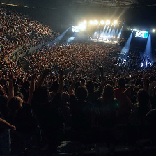

```python
imagen = load_img('concert.jpg', target_size=(224, 224))
imagen
```

```python
imagen = img_to_array(imagen)
imagen = imagen.reshape((1, imagen.shape[0], imagen.shape[1],imagen.shape[2]))
imagen = preprocess_input(imagen)
```

```python
prediccion = modelo.predict(imagen)
etiquetas = decode_predictions(prediccion)
cont = 0
for etiqueta in etiquetas[0]:
    print('TOP',cont,': %s (%.2f%%)' % (etiqueta[1], etiqueta[2]*100))
    cont +=1
```

```
TOP 0 : stage (87.11%)
TOP 1 : spotlight (2.94%)
TOP 2 : theater_curtain (2.54%)
TOP 3 : cinema (2.44%)
TOP 4 : fountain (1.56%)
```

#### Img 2: Serra (Serrella)

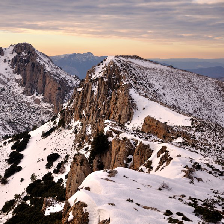

```python
imagen = load_img('serrella.jpg', target_size=(224, 224))
imagen
```

```python
imagen = img_to_array(imagen)
imagen = imagen.reshape((1, imagen.shape[0], imagen.shape[1],
imagen.shape[2]))
imagen = preprocess_input(imagen)
```

```python
prediccion = modelo.predict(imagen)
etiquetas = decode_predictions(prediccion)
cont = 0
for etiqueta in etiquetas[0]:
    print('TOP',cont,': %s (%.2f%%)' % (etiqueta[1], etiqueta[2]*100))
    cont +=1
```

```
TOP 0 : alp (98.42%)
TOP 1 : cliff (0.75%)
TOP 2 : valley (0.15%)
TOP 3 : mountain_tent (0.12%)
TOP 4 : ski (0.12%)
```

#### Img 3: Cireres:

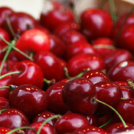

```python
imagen = load_img('cireres_planes.jpg', target_size=(224, 224))
imagen
```

```python
imagen = img_to_array(imagen)
imagen = imagen.reshape((1, imagen.shape[0], imagen.shape[1],imagen.shape[2]))
imagen = preprocess_input(imagen)
```

```python
prediccion = modelo.predict(imagen)
etiquetas = decode_predictions(prediccion)
cont = 0
for etiqueta in etiquetas[0]:
    print('TOP',cont,': %s (%.2f%%)' % (etiqueta[1], etiqueta[2]*100))
    cont +=1
```

```
TOP 0 : pomegranate (88.25%)
TOP 1 : grocery_store (3.80%)
TOP 2 : strawberry (2.40%)
TOP 3 : bell_pepper (1.15%)
TOP 4 : buckeye (1.08%)
```

Ho confón amb una magrana, però pot considerar-se similar.

#### Img 4: Arròs al forn

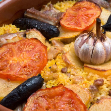

```python
imagen = load_img('arros_al_forn.jpg', target_size=(224, 224))
imagen
```

```python
imagen = img_to_array(imagen)
imagen = imagen.reshape((1, imagen.shape[0], imagen.shape[1], imagen.shape[2]))
imagen = preprocess_input(imagen)
```

```python
prediccion = modelo.predict(imagen)
etiquetas = decode_predictions(prediccion)
cont = 0
for etiqueta in etiquetas[0]:
    print('TOP',cont,': %s (%.2f%%)' % (etiqueta[1], etiqueta[2]*100))
    cont +=1
```

```
TOP 0 : hot_pot (24.79%)
TOP 1 : pizza (18.44%)
TOP 2 : Dutch_oven (10.75%)
TOP 3 : acorn_squash (10.13%)
TOP 4 : frying_pan (6.73%)
```

#### Img 5: El meu poble:

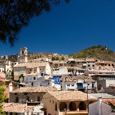

```python
imagen = load_img('planes.jpg', target_size=(224, 224))
imagen
```

```python
imagen = img_to_array(imagen)
imagen = imagen.reshape((1, imagen.shape[0], imagen.shape[1],imagen.shape[2]))
imagen = preprocess_input(imagen)
```

```python
prediccion = modelo.predict(imagen)
etiquetas = decode_predictions(prediccion)
cont = 0
for etiqueta in etiquetas[0]:
    print('TOP',cont,': %s (%.2f%%)' % (etiqueta[1], etiqueta[2]*100))
    cont +=1
```

```
TOP 0 : monastery (27.66%)
TOP 1 : stupa (21.35%)
TOP 2 : dome (19.24%)
TOP 3 : mosque (11.27%)
TOP 4 : palace (11.13%)
```

### Repite el ejercicio usando otro de los modelos que tiene preentrenados Keras

```python
from keras.applications.efficientnet  import EfficientNetB5
modelo = EfficientNetB5()
print(modelo.summary())
```

```
Downloading data from https://storage.googleapis.com/keras-applications/efficientnetb5.h5
Model: "efficientnetb5"
__________________________________________________________________________________________________
Layer (type)                    Output Shape         Param #     Connected to
==================================================================================================
input_13 (InputLayer)           [(None, 456, 456, 3) 0
__________________________________________________________________________________________________
rescaling_1 (Rescaling)         (None, 456, 456, 3)  0           input_13[0][0]
__________________________________________________________________________________________________
normalization_1 (Normalization) (None, 456, 456, 3)  7           rescaling_1[0][0]
__________________________________________________________________________________________________
stem_conv_pad (ZeroPadding2D)   (None, 457, 457, 3)  0           normalization_1[0][0]
__________________________________________________________________________________________________
stem_conv (Conv2D)              (None, 228, 228, 48) 1296        stem_conv_pad[0][0]
__________________________________________________________________________________________________
stem_bn (BatchNormalization)    (None, 228, 228, 48) 192         stem_conv[0][0]
__________________________________________________________________________________________________
stem_activation (Activation)    (None, 228, 228, 48) 0           stem_bn[0][0]
__________________________________________________________________________________________________
block1a_dwconv (DepthwiseConv2D (None, 228, 228, 48) 432         stem_activation[0][0]
__________________________________________________________________________________________________
block1a_bn (BatchNormalization) (None, 228, 228, 48) 192         block1a_dwconv[0][0]
__________________________________________________________________________________________________
block1a_activation (Activation) (None, 228, 228, 48) 0           block1a_bn[0][0]
__________________________________________________________________________________________________
block1a_se_squeeze (GlobalAvera (None, 48)           0           block1a_activation[0][0]
__________________________________________________________________________________________________
block1a_se_reshape (Reshape)    (None, 1, 1, 48)     0           block1a_se_squeeze[0][0]
__________________________________________________________________________________________________
block1a_se_reduce (Conv2D)      (None, 1, 1, 12)     588         block1a_se_reshape[0][0]
__________________________________________________________________________________________________
block1a_se_expand (Conv2D)      (None, 1, 1, 48)     624         block1a_se_reduce[0][0]
__________________________________________________________________________________________________
block1a_se_excite (Multiply)    (None, 228, 228, 48) 0           block1a_activation[0][0]
                                                                 block1a_se_expand[0][0]
__________________________________________________________________________________________________
block1a_project_conv (Conv2D)   (None, 228, 228, 24) 1152        block1a_se_excite[0][0]
__________________________________________________________________________________________________
block1a_project_bn (BatchNormal (None, 228, 228, 24) 96          block1a_project_conv[0][0]
__________________________________________________________________________________________________
```

[output cut: 1184 more lines]

```
top_bn (BatchNormalization)     (None, 15, 15, 2048) 8192        top_conv[0][0]
__________________________________________________________________________________________________
top_activation (Activation)     (None, 15, 15, 2048) 0           top_bn[0][0]
__________________________________________________________________________________________________
avg_pool (GlobalAveragePooling2 (None, 2048)         0           top_activation[0][0]
__________________________________________________________________________________________________
top_dropout (Dropout)           (None, 2048)         0           avg_pool[0][0]
__________________________________________________________________________________________________
predictions (Dense)             (None, 1000)         2049000     top_dropout[0][0]
==================================================================================================
Total params: 30,562,527
Trainable params: 30,389,784
Non-trainable params: 172,743
__________________________________________________________________________________________________
None
```

#### Img 1: Concert:

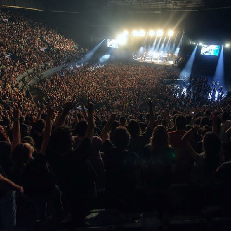

```python
imagen = load_img('concert.jpg', target_size=(456, 456))
imagen
```

```python
imagen = img_to_array(imagen)
imagen = imagen.reshape((1, imagen.shape[0], imagen.shape[1],imagen.shape[2]))
imagen = preprocess_input(imagen)
prediccion = modelo.predict(imagen)
etiquetas = decode_predictions(prediccion)
cont = 0
for etiqueta in etiquetas[0]:
    print('TOP',cont,': %s (%.2f%%)' % (etiqueta[1], etiqueta[2]*100))
    cont +=1
```

```
TOP 0 : stage (25.84%)
TOP 1 : dam (14.59%)
TOP 2 : spotlight (9.23%)
TOP 3 : volcano (8.55%)
TOP 4 : torch (3.92%)
```

#### Img 2: Serra (Serrella)

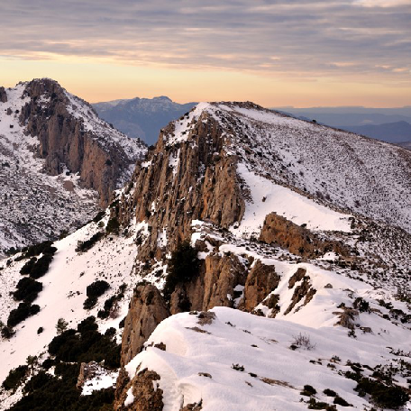

```python
imagen = load_img('serrella.jpg', target_size=(456, 456))
imagen
```

```python
imagen = img_to_array(imagen)
imagen = imagen.reshape((1, imagen.shape[0], imagen.shape[1],
imagen.shape[2]))
imagen = preprocess_input(imagen)
prediccion = modelo.predict(imagen)
etiquetas = decode_predictions(prediccion)
cont = 0
for etiqueta in etiquetas[0]:
    print('TOP',cont,': %s (%.2f%%)' % (etiqueta[1], etiqueta[2]*100))
    cont +=1
```

```
TOP 0 : alp (68.40%)
TOP 1 : valley (6.67%)
TOP 2 : cliff (5.74%)
TOP 3 : promontory (1.00%)
TOP 4 : volcano (0.52%)
```

#### Img 3: Cireres

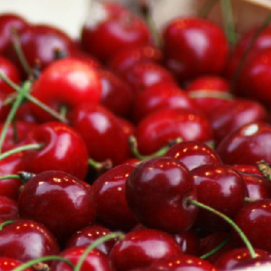

```python
imagen = load_img('cireres_planes.jpg', target_size=(456, 456))
imagen
```

```python
imagen = img_to_array(imagen)
imagen = imagen.reshape((1, imagen.shape[0], imagen.shape[1],imagen.shape[2]))
imagen = preprocess_input(imagen)
prediccion = modelo.predict(imagen)
etiqueta = decode_predictions(prediccion)
etiqueta = etiqueta[0][0]
print('%s (%.2f%%)' % (etiqueta[1], etiqueta[2]*100))
```

```
bell_pepper (55.50%)
```

#### Img 4: Arròs al forn

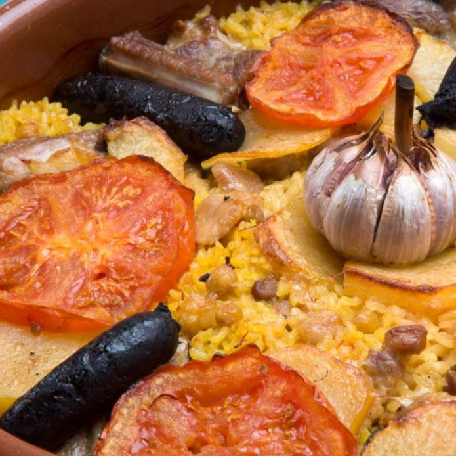

```python
imagen = load_img('arros_al_Forn.jpg', target_size=(456, 456))
imagen
```

```python
imagen = img_to_array(imagen)
imagen = imagen.reshape((1, imagen.shape[0], imagen.shape[1],imagen.shape[2]))
imagen = preprocess_input(imagen)
prediccion = modelo.predict(imagen)
etiqueta = decode_predictions(prediccion)
etiqueta = etiqueta[0][0]
print('%s (%.2f%%)' % (etiqueta[1], etiqueta[2]*100))
```

```
spaghetti_squash (9.13%)
```

#### Img 5: El meu poble

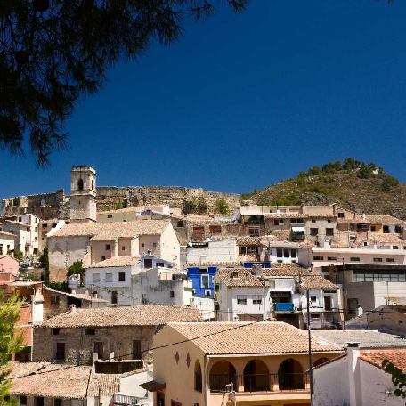

```python
imagen = load_img('planes.jpg', target_size=(456, 456))
imagen
```

```python
imagen = img_to_array(imagen)
imagen = imagen.reshape((1, imagen.shape[0], imagen.shape[1],imagen.shape[2]))
imagen = preprocess_input(imagen)
prediccion = modelo.predict(imagen)
etiqueta = decode_predictions(prediccion)
etiqueta = etiqueta[0][0]
print('%s (%.2f%%)' % (etiqueta[1], etiqueta[2]*100))
```

```
monastery (32.64%)
```